# COVID-19 Testing Data and Trend in Canada

Kuan Liu, kuan.liu@mail.utoronto.ca

Alexandra Bushby, alex.bushby@mail.utoronto.ca

**Date Created:** 2020-03-25

**Date Updated:** 2020-03-27

**Code Avaliable at** https://github.com/Kuan-Liu/Kuan-Liu-testing_can

## Acknowledgement

Data used in this repostory are extracted from the data speardsheet posted by the COVID-19 Canada Open Data Working Group (https://github.com/ishaberry/Covid19Canada). This working group, lead by Isha Berry and Jean-Paul R. Soucy from Dalla Lana School of Public Health, Unviersity of Toronto, has created an interactive dashboard on Canadian COVID-19 epidemiology data. I direct readers to visit the dashboard site at https://art-bd.shinyapps.io/covid19canada/.

## Nation-wide total number of tests to date

As of March 26, 2020 (6 pm EDT), the total number of patients tested in Canada is 161,603 and the total number of patients tested per 10,000 population in Canada is around 42.

(Data source: https://www.canada.ca/en/public-health/services/diseases/2019-novel-coronavirus-infection.html).

## Total number of tests to date province and territory

- **Highlights**
  - **Alberta, British Columbia and Saskatchewan are the top three provinces ranking by the number of tests per 10,000 population.**
  - **Northwest territories and Yukon reported over 100 tests per 10,000 population, highest in Canada.**
  - **Only 3 provinces, Ontario, Quebec and Prince Edward Island, reported the number of tests pending results. There appears to be a back log of test reporting in Ontario.**

Reported testing data province and territory, public data accessed online as of March 26, 2020 (8 pm EDT). Reported positive tests include resolved and deceased cases.

| Province | Reported Positive | Reported Negative | Reported Pending | Total | Est. Population | Total per 10,000 people |
| --- | --- | --- | --- | --- | --- | --- |
| AB | 486 | 36174 | - | 36660 | 4371316 | 84 |
| BC | 725 | - | - | 31739 | 5071336 | 63 |
| MB | 36 | - | - | 5606 | 1369465 | 41 |
| NB | 33 | 1795 | - | 1828 | 776827 | 24 |
| NL | 82 | 1409 | - | 1491 | 521542 | 29 |
| NS | 73 | 3201 | - | 3274 | 971395 | 34 |
| ON | 858 | 26727 | 10965 | 38550 | 14566547 | 26 |
| PEI | 5 | 339 | 212 | 556 | 156947 | 35 |
| QC | 1629 | 31854 | 2622 | 36105 | 8484965 | 43 |
| SK | 95 | - | - | 6915 | 1174462 | 59 |
| NWT | 1 | 263 | 295 | 559 | 44826 | 125 |
| NU | 0 | 50 | 116 | 166 | 38780 | 43 |
| YT | 3 | 412 | 102 | 517 | 40854 | 127 |

- **Highlights**
  - **Nunavut has no confirmed case yet.**
  - **Among the 3 provinces that reported pending tests (Quebec, Ontario and Prince Edward Island), Quebec has the highest proportion of positive tests (4.5%).**
  - **Among the 4 provinces that reported negative tests but not tests awaiting for results (Alberta, New Brunswick, Newfoundland and Labrador and Nova Scotia), Newfoundland and Labrador has the highest proportion of positive tests (5.5%). This can be interpreted as for every 100 tests completed (with known results) in Newfoundland and Labrador, we expect around 5 to 6 of them to be postive.**

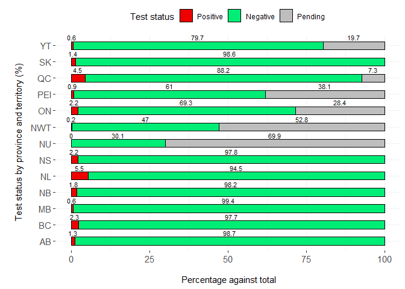

##### Footnote: For provinces that don’t report pending cases, we will assume a binary testing status (postive or negative).

## Cumulative tests by province between March 15 - March 26, 2020

- **Highlights**
  - **Consistent increase of testing capacity over the 12-day window across Canada. Quebec displays a sharp testing increase on March 25, 2020. British Columbia displays a shart testing increase on March 20, 2020.**
  - **Alberta, Ontario, British Columbia and Quebec are the top 4 provinces ranked by the total number of cumulative tests**
  - **Alberta, British Columbia and Quebec also rank high among the 10 provinces by the total number of tests conducted per 10,000 population. It seems Ontario is falling slight behind the above three provinces on the testing capacity per capita.**
  - **Despite having low numbers of cumulative tests, the three territories demonstrate above national average testing capacity per capita.**

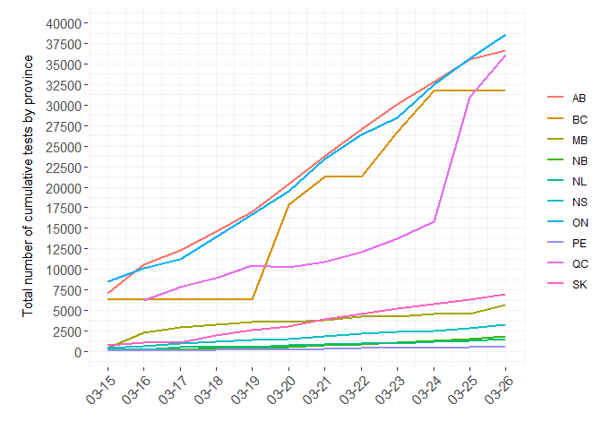

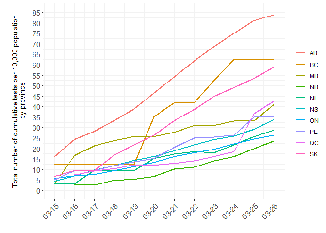

## Cumulative tests by territory

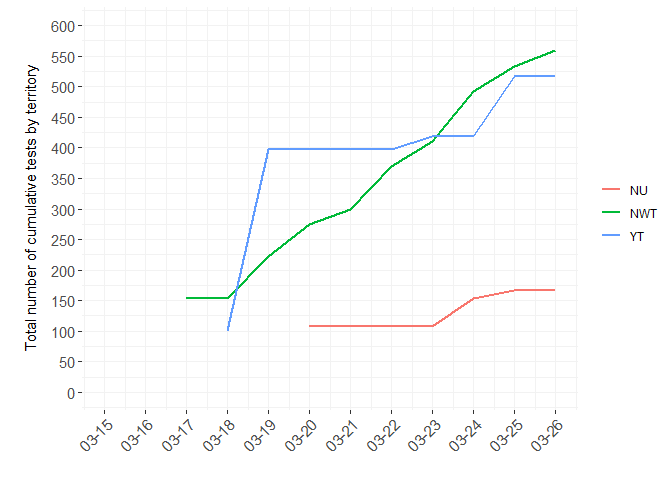

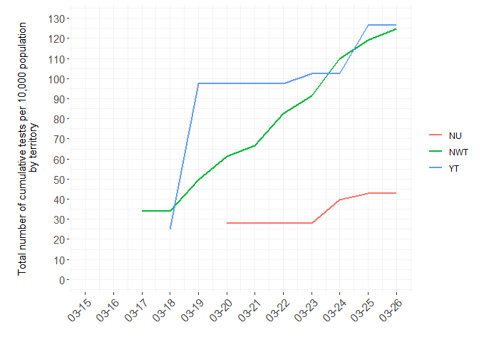

## Important jurisdiction-specific dates

- March 22, 2020, Nova Scotia declared state of emergency
- March 20, 2020, Manitoba declares state of emergency
- March 20, 2020, Northwest Territories declared public health emergency
- March 19, 2020, New Brunswick declared state of emergency
- March 18, 2020, Newfoundland and Labrador declared public health emergency
- March 18, 2020, Yukon declared public health emergency
- March 18, 2020, Saskatchewan declared state of emergency
- March 18, 2020, British Columbia declared provintial state of emergency
- March 17, 2020, Nunavat declared public health emergency
- March 17, 2020, Alberta declared state of emergency
- March 17, 2020, Ontario declared state of emergency
- March 16, 2020, Prince Edward Island declared public health emergency
- March 13, 2020, Quebec declared health emergency

# Reference

- COVID-19 Canada Open Data Working Group. Epidemiological Data from the COVID-19 Outbreak in Canada. https://github.com/ishaberry/Covid19Canada. (2020-03-25).
- [National testing data to date] https://www.canada.ca/en/public-health/services/diseases/2019-novel-coronavirus-infection.html and https://www.ctvnews.ca/health/coronavirus/tracking-every-case-of-covid-19-in-canada-1.4852102
- [Ontario testing data to date] https://www.ontario.ca/page/2019-novel-coronavirus
- [British Columbia testing data to date] http://www.bccdc.ca/about/news-stories/stories/2020/information-on-novel-coronavirus
- [Alberta testing data to date] https://www.alberta.ca/covid-19-alberta-data.aspx
- [Saskatchewan testing data to date] https://www.saskatchewan.ca/government/health-care-administration-and-provider-resources/treatment-procedures-and-guidelines/emerging-public-health-issues/2019-novel-coronavirus/cases-and-risk-of-covid-19-in-saskatchewan
- [Manitoba testing data to date] https://www.gov.mb.ca/covid19/
- [Quebec testing data to date] https://www.quebec.ca/en/health/health-issues/a-z/2019-coronavirus/situation-coronavirus-in-quebec/
- [Newfoundland and Labrador testing data to date] https://www.gov.nl.ca/covid-19/
- [New Brunswick testing data to date] https://www2.gnb.ca/content/gnb/en/departments/ocmoh/cdc/content/respiratory_diseases/coronavirus.html
- [Nova Scotia testing data to date] https://novascotia.ca/coronavirus/#cases
- [Prince Edward Island testing data to date] https://www.princeedwardisland.ca/en/topic/covid-19
- [Yukon testing data to date] https://yukon.ca/en/health-and-wellness/health-concerns-diseases-and-conditions/covid-19-information
- [Northwest Territories testing data to date] https://www.hss.gov.nt.ca/en/services/coronavirus-disease-covid-19
- [Nunavut testing data to date] https://www.gov.nu.ca/health/information/covid-19-novel-coronavirus